# Unsupervised Learning Project

## 1. Data Understanding: 10marks

```python
import numpy as np
import pandas as pd
import seaborn as sns
import matplotlib.pyplot as plt
%matplotlib inline
import warnings
warnings.filterwarnings('ignore')
```

### a. Read ‘Car name.csv’ as a DataFrame and assign it to a variable. [1 Mark]

```python
#Reading csv
df1 = pd.read_csv('Car+name.csv')
```

### b. Read ‘Car-Attributes.json as a DataFrame and assign it to a variable. [1 Mark]

```python
#Reading json
df2 = pd.read_json('Car-Attributes-1.json')
```

```python
df1.head()
```

|  | car_name |
| --- | --- |
| 0 | chevrolet chevelle malibu |
| 1 | buick skylark 320 |
| 2 | plymouth satellite |
| 3 | amc rebel sst |
| 4 | ford torino |

```python
df2.head()
```

|  | mpg | cyl | disp | hp | wt | acc | yr | origin |
| --- | --- | --- | --- | --- | --- | --- | --- | --- |
| 0 | 18.0 | 8 | 307.0 | 130 | 3504 | 12.0 | 70 | 1 |
| 1 | 15.0 | 8 | 350.0 | 165 | 3693 | 11.5 | 70 | 1 |
| 2 | 18.0 | 8 | 318.0 | 150 | 3436 | 11.0 | 70 | 1 |
| 3 | 16.0 | 8 | 304.0 | 150 | 3433 | 12.0 | 70 | 1 |
| 4 | 17.0 | 8 | 302.0 | 140 | 3449 | 10.5 | 70 | 1 |

### c. Merge both the DataFrames together to form a single DataFrame [2 Mark]

```python
#Merging the 2 dataframes into a single dataframe
df = pd.concat([df1, df2], axis=1)
```

```python
df.head()
```

|  | car_name | mpg | cyl | disp | hp | wt | acc | yr | origin |
| --- | --- | --- | --- | --- | --- | --- | --- | --- | --- |
| 0 | chevrolet chevelle malibu | 18.0 | 8 | 307.0 | 130 | 3504 | 12.0 | 70 | 1 |
| 1 | buick skylark 320 | 15.0 | 8 | 350.0 | 165 | 3693 | 11.5 | 70 | 1 |
| 2 | plymouth satellite | 18.0 | 8 | 318.0 | 150 | 3436 | 11.0 | 70 | 1 |
| 3 | amc rebel sst | 16.0 | 8 | 304.0 | 150 | 3433 | 12.0 | 70 | 1 |
| 4 | ford torino | 17.0 | 8 | 302.0 | 140 | 3449 | 10.5 | 70 | 1 |

### d. Print 5 point summary of the numerical features and share insights. [1 Marks]

```python
#Printing 5 point summary using describe function
df.describe()
```

|  | mpg | cyl | disp | wt | acc | yr | origin |
| --- | --- | --- | --- | --- | --- | --- | --- |
| count | 398.000000 | 398.000000 | 398.000000 | 398.000000 | 398.000000 | 398.000000 | 398.000000 |
| mean | 23.514573 | 5.454774 | 193.425879 | 2970.424623 | 15.568090 | 76.010050 | 1.572864 |
| std | 7.815984 | 1.701004 | 104.269838 | 846.841774 | 2.757689 | 3.697627 | 0.802055 |
| min | 9.000000 | 3.000000 | 68.000000 | 1613.000000 | 8.000000 | 70.000000 | 1.000000 |
| 25% | 17.500000 | 4.000000 | 104.250000 | 2223.750000 | 13.825000 | 73.000000 | 1.000000 |
| 50% | 23.000000 | 4.000000 | 148.500000 | 2803.500000 | 15.500000 | 76.000000 | 1.000000 |
| 75% | 29.000000 | 8.000000 | 262.000000 | 3608.000000 | 17.175000 | 79.000000 | 2.000000 |
| max | 46.600000 | 8.000000 | 455.000000 | 5140.000000 | 24.800000 | 82.000000 | 3.000000 |

```python
# 'hp' attribute does not show up in describe output indicating there could be non-numeric values in it
# There is considerable right skew in cyl & disp attributes (skew in origin column is irrelevant as each number represents categories probably denoting continents)
# The cars in the dataset have manufacturing year ranging from 1970 to 1982 (min & max from yr attribute)
```

## 2. Data Preparation and Analysis: 20marks

### a. Check and print feature-wise percentage of missing values present in the data and impute with

### the best suitable approach. [2 Mark]

```python
df.isnull().sum()*100/df.shape[0]
```

```
car_name    0.0
mpg         0.0
cyl         0.0
disp        0.0
hp          0.0
wt          0.0
acc         0.0
yr          0.0
origin      0.0
dtype: float64
```

```python
# There is no missing value. Let us check for non-numeric entries in hp column
```

```python
temp = pd.DataFrame(df['hp'].str.isdigit())
temp[temp['hp']==False]
```

|  | hp |
| --- | --- |
| 32 | False |
| 126 | False |
| 330 | False |
| 336 | False |
| 354 | False |
| 374 | False |

```python
#Replacing those non-numeric values with null values so that they can be imputed
df['hp'].iloc[[32, 126, 330, 336, 354, 374]] = np.NAN
```

```python
df.isnull().sum()
```

```
car_name    0
mpg         0
cyl         0
disp        0
hp          6
wt          0
acc         0
yr          0
origin      0
dtype: int64
```

```python
#Creating a dataframe with car_name attribute removed, since KNN Imputer does not work when there are non-numeric attributes
df_temp = df.drop(columns=['car_name'], axis=1)
from sklearn.impute import KNNImputer
imputer = KNNImputer(n_neighbors=5)
df_temp = pd.DataFrame(imputer.fit_transform(df_temp),columns = df_temp.columns)
```

```python
#Replacing hp column in original dataframe with the hp column from imputed dataframe
df['hp'] = df_temp['hp']
```

```python
df.isnull().sum()
```

```
car_name    0
mpg         0
cyl         0
disp        0
hp          0
wt          0
acc         0
yr          0
origin      0
dtype: int64
```

```python
#Checking the imputed values
df['hp'].iloc[[32, 126, 330, 336, 354, 374]]
```

```
32      62.0
126    107.6
330     64.6
336    112.8
354     76.0
374     88.2
Name: hp, dtype: float64
```

### b. Check for duplicate values in the data and impute with the best suitable approach. [1 Mark]

```python
#Checking for duplicates based on all columns.
#Duplicates should not be based on a single column like car_name in this case since there could be multiple variants
#with the same car_name manufactured in different years, having different specifications etc.
dups = df.duplicated()
print(dups.sum())
```

```
0
```

```python
# Seems there are no duplicates based on all columns.
```

### c. Plot a pairplot for all features. [1 Marks]

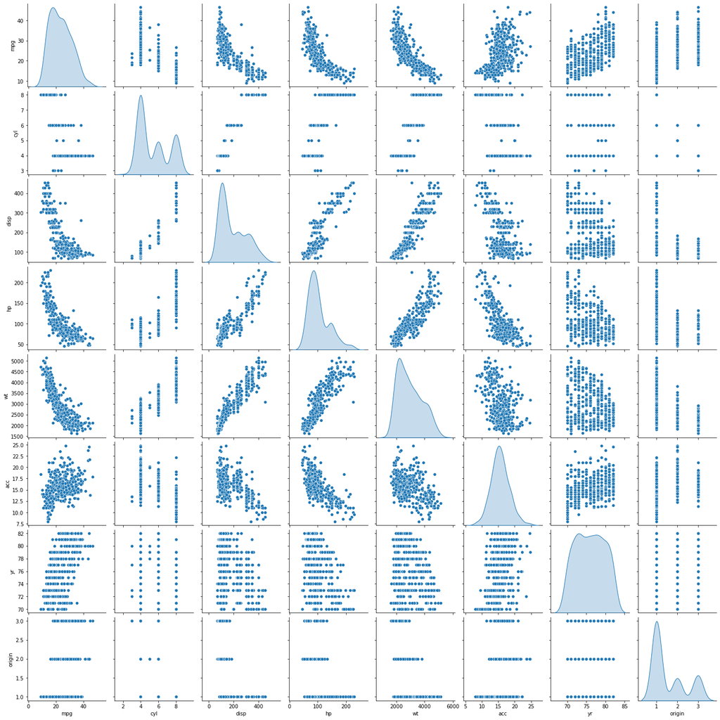

```python
sns.pairplot(df, diag_kind = 'kde')
```

```python
# In the distribution plots (diagonal), we visually observe 3 peaks at most in few features
# So there could be at least 3 natural clusters
# There is strong correlation between many features as can be inferred from the elongated plots
# There is strong correlation for many independent attributes with the target attribute (mpg) as well
# An exception would be the accelaration attribute which has sort of a round shaped plot with mpg attribute indicating minimal correlation
```

### d. Visualize a scatterplot for ‘wt’ and ‘disp’. Datapoints should be distinguishable by ‘cyl’. [1 Marks]

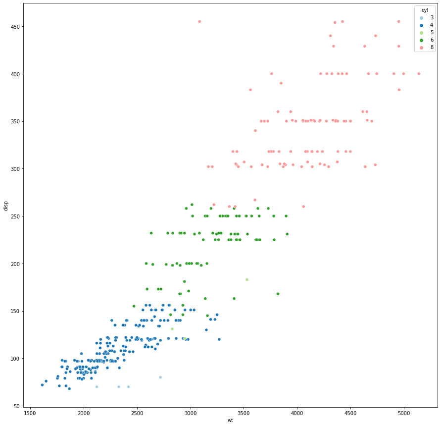

```python
plt.figure(figsize=(15,15))
sns.scatterplot(x='wt', y='disp', hue='cyl', data=df, palette='Paired')
```

### e. Share insights for Q2.d. [1 Marks]

```python
# As weight increases, displacement also increases. There seems to be strong positive correlation.
# Displacement also increases as number of cylinders increases (positive correlation)
# Datapoints seem to form clusters based on number of cylinders
# It appears most cars have 4 or 8 cylinders
```

### f. Visualize a scatterplot for ‘wt’ and ’mpg’. Datapoints should be distinguishable by ‘cyl’. [1 Marks]

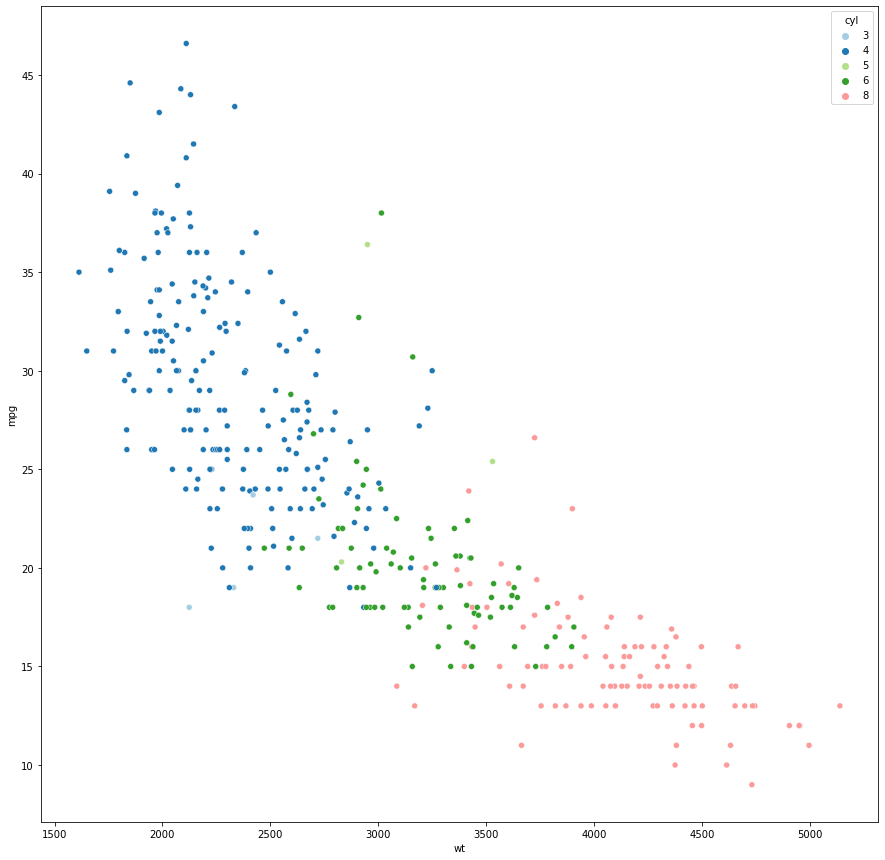

```python
plt.figure(figsize=(15,15))
sns.scatterplot(x='wt', y='mpg', hue='cyl', data=df, palette='Paired')
```

### g. Share insights for Q2.f. [1 Marks]

```python
# Miles per Gallon decreases as weight increases (negative correlation).
# For low values of weight, there is a lot of spread/variance in miles per gallon. The spread decreases as weight increases.
# Miles per Gallon mostly decreases as number of cylinders increases (negative correlation)
# Here also we see clustering based on number of cylinders
```

### h. Check for unexpected values in all the features and datapoints with such values. [2 Marks]

```python
# Creating a new dataframe with only the columns that are supposed to be completely numeric
df_temp = df.drop(columns=['car_name'], axis=1)
```

```python
# Checking if there is any non-numeric value in the whole data frame
df_temp[~df_temp.applymap(np.isreal).all(1)]
```

|  | mpg | cyl | disp | hp | wt | acc | yr | origin |
| --- | --- | --- | --- | --- | --- | --- | --- | --- |

```python
# There is no non-numeric value
```

## 3. Clustering: 30marks

### a. Apply K-Means clustering for 2 to 10 clusters. [3 Marks]

```python
df.info()
```

```
<class 'pandas.core.frame.DataFrame'>
RangeIndex: 398 entries, 0 to 397
Data columns (total 9 columns):
 #   Column    Non-Null Count  Dtype
---  ------    --------------  -----
 0   car_name  398 non-null    object
 1   mpg       398 non-null    float64
 2   cyl       398 non-null    int64
 3   disp      398 non-null    float64
 4   hp        398 non-null    float64
 5   wt        398 non-null    int64
 6   acc       398 non-null    float64
 7   yr        398 non-null    int64
 8   origin    398 non-null    int64
dtypes: float64(4), int64(4), object(1)
memory usage: 28.1+ KB
```

```python
df_head = df.head(397) # making copy of the top 397 rows of non-scaled dataframe for later use
df_tail = df.tail(1) # making copy of the bottom row of non-scaled dataframe for later use
```

```python
# Before we use K-Means clustering, we need to standardize the data first
from scipy.stats import zscore
df = df.drop(columns=['car_name'], axis=1) #Dropping non-numeric attribute before standardization
dfz = df.apply(zscore)
dfz.head()
```

|  | mpg | cyl | disp | hp | wt | acc | yr | origin |
| --- | --- | --- | --- | --- | --- | --- | --- | --- |
| 0 | -0.706439 | 1.498191 | 1.090604 | 0.674189 | 0.630870 | -1.295498 | -1.627426 | -0.715145 |
| 1 | -1.090751 | 1.498191 | 1.503514 | 1.588038 | 0.854333 | -1.477038 | -1.627426 | -0.715145 |
| 2 | -0.706439 | 1.498191 | 1.196232 | 1.196388 | 0.550470 | -1.658577 | -1.627426 | -0.715145 |
| 3 | -0.962647 | 1.498191 | 1.061796 | 1.196388 | 0.546923 | -1.295498 | -1.627426 | -0.715145 |
| 4 | -0.834543 | 1.498191 | 1.042591 | 0.935289 | 0.565841 | -1.840117 | -1.627426 | -0.715145 |

```python
# Setting aside the last row from the dataframe for using as a new datapoint later
dfz_tail = dfz.tail(1)
dfz = dfz.head(397)
print(dfz_tail.shape)
dfz.shape
```

```
(1, 8)
```

```
(397, 8)
```

```python
# K-Means Clustering
from sklearn.cluster import KMeans
from scipy.spatial.distance import cdist
from sklearn.metrics import silhouette_score
clusters=range(2,11)
inertia=[] #Inertia is the sum of squared distance between the datapoints and their centroid. Lower the value, tighter/better the cluster is
meanDistortions=[] #Mean Distortion is the average of the euclidean squared distance from the centroid of the respective clusters. Lower the value, tighter/better the cluster is
silht_score = [] #Cluster metric based on both intra-cluster distance and inter-cluster distance. Higher the better. (Range: -1 to 1)

for k in clusters:
    model=KMeans(n_clusters=k, random_state=1)
    model.fit(dfz) #For each datapoint, the distance from its centroid is calculated at this step
    prediction=model.predict(dfz) #predicts to which cluster each datapoint belongs to
    #Mean Distortion, Inertia and Silhouette Score are different metrics that can be used to find the actual number of natural clusters present
    inertia.append(model.inertia_)
    meanDistortions.append(sum(np.min(cdist(dfz, model.cluster_centers_, 'euclidean'), axis=1)) / dfz.shape[0])
    silht_score.append(silhouette_score(dfz, prediction))

print('Inertia:', inertia)
print('Mean Distortion:', meanDistortions)
print('Silhouette Score:', silht_score)
```

```
Inertia: [1582.653734409746, 1184.3421566525271, 983.9867682282254, 827.7139303216995, 747.8215135812886, 677.6980314964347, 634.7704392763557, 589.4005956666056, 557.9531605421138]
Mean Distortion: [1.912990246406798, 1.6287267236935772, 1.4770637020435684, 1.3358450462769489, 1.2776013481093478, 1.2135482724368205, 1.1820549439176753, 1.142226220905001, 1.100680309133422]
Silhouette Score: [0.4152455911826263, 0.32562967865745823, 0.3128147103885642, 0.33275373035243183, 0.33842041569808445, 0.29393818323593296, 0.2911478201939655, 0.2780134826080768, 0.27424194452595535]
```

### b. Plot a visual and find elbow point. [2 Marks]

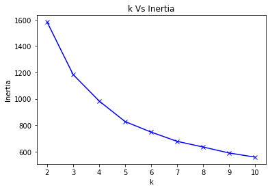

```python
#Plot based on Inertia
plt.plot(clusters, inertia, 'bx-')
plt.xlabel('k')
plt.ylabel('Inertia')
plt.title('k Vs Inertia')
```

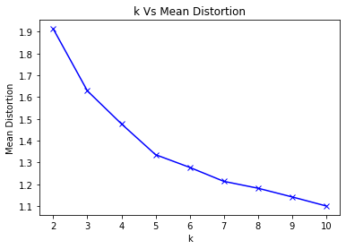

```python
#Plot based on Mean Distortion
plt.plot(clusters, meanDistortions, 'bx-')
plt.xlabel('k')
plt.ylabel('Mean Distortion')
plt.title('k Vs Mean Distortion')
```

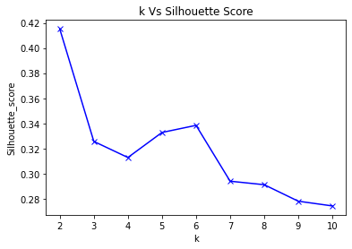

```python
#Plot based on Silhouette Score
plt.plot(clusters, silht_score, 'bx-')
plt.xlabel('k')
plt.ylabel('Silhouette_score')
plt.title('k Vs Silhouette Score')
```

### c. On the above visual, highlight which are the possible Elbow points. [1 Marks]

```python
# From visual analysis, we can see that there is steep drop in Inertia and Mean Distortion till k=5
# Hence k=5 is the elbow point and is probably the actual number of natural clusters in our data
```

```python
# Alternatively, the knee or elbow point can be identified using KneeLocator algorithm which finds the point of maximum curvature
from kneed import KneeLocator, DataGenerator
#Knee point based on Inertia
kn = KneeLocator(clusters, inertia, curve='convex', direction='decreasing')
print(kn.knee)
```

```
5
```

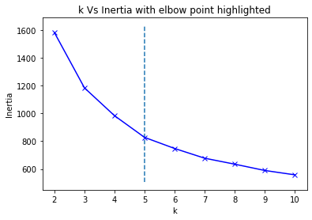

```python
#Inertia plot with elbow point highlighted
plt.xlabel('k')
plt.ylabel('Inertia')
plt.plot(clusters, inertia, 'bx-')
plt.title('k Vs Inertia with elbow point highlighted')
plt.vlines(kn.knee, plt.ylim()[0], plt.ylim()[1], linestyles='dashed')
```

```python
#Knee point based on Mean Distortion
kn2 = KneeLocator(clusters, meanDistortions, curve='convex', direction='decreasing')
print(kn2.knee)
```

```
5
```

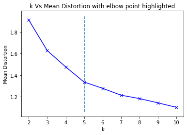

```python
#Mean Distortion plot with elbow point highlighted
plt.xlabel('k')
plt.ylabel('Mean Distortion')
plt.plot(clusters, meanDistortions, 'bx-')
plt.title('k Vs Mean Distortion with elbow point highlighted')
plt.vlines(kn2.knee, plt.ylim()[0], plt.ylim()[1], linestyles='dashed')
```

### d. Train a K-means clustering model once again on the optimal number of clusters. [3 Marks]

```python
final_model=KMeans(n_clusters=5, random_state=1) # Optimal number of clusters was identified as 5
final_model.fit(dfz) #Training the model
prediction=final_model.predict(dfz) #predicts to which cluster each datapoint belongs to
```

### e. Add a new feature in the DataFrame which will have labels based upon cluster value. [2 Marks]

```python
df_head['Cluster ID'] = prediction # Adding the cluster prediction as a feature to the original dataframe
df_head.head(50)
```

|  | car_name | mpg | cyl | disp | hp | wt | acc | yr | origin | Cluster ID |
| --- | --- | --- | --- | --- | --- | --- | --- | --- | --- | --- |
| 0 | chevrolet chevelle malibu | 18.0 | 8 | 307.0 | 130.0 | 3504 | 12.0 | 70 | 1 | 2 |
| 1 | buick skylark 320 | 15.0 | 8 | 350.0 | 165.0 | 3693 | 11.5 | 70 | 1 | 2 |
| 2 | plymouth satellite | 18.0 | 8 | 318.0 | 150.0 | 3436 | 11.0 | 70 | 1 | 2 |
| 3 | amc rebel sst | 16.0 | 8 | 304.0 | 150.0 | 3433 | 12.0 | 70 | 1 | 2 |
| 4 | ford torino | 17.0 | 8 | 302.0 | 140.0 | 3449 | 10.5 | 70 | 1 | 2 |
| 5 | ford galaxie 500 | 15.0 | 8 | 429.0 | 198.0 | 4341 | 10.0 | 70 | 1 | 2 |
| 6 | chevrolet impala | 14.0 | 8 | 454.0 | 220.0 | 4354 | 9.0 | 70 | 1 | 2 |
| 7 | plymouth fury iii | 14.0 | 8 | 440.0 | 215.0 | 4312 | 8.5 | 70 | 1 | 2 |
| 8 | pontiac catalina | 14.0 | 8 | 455.0 | 225.0 | 4425 | 10.0 | 70 | 1 | 2 |
| 9 | amc ambassador dpl | 15.0 | 8 | 390.0 | 190.0 | 3850 | 8.5 | 70 | 1 | 2 |
| 10 | dodge challenger se | 15.0 | 8 | 383.0 | 170.0 | 3563 | 10.0 | 70 | 1 | 2 |
| 11 | plymouth 'cuda 340 | 14.0 | 8 | 340.0 | 160.0 | 3609 | 8.0 | 70 | 1 | 2 |
| 12 | chevrolet monte carlo | 15.0 | 8 | 400.0 | 150.0 | 3761 | 9.5 | 70 | 1 | 2 |
| 13 | buick estate wagon (sw) | 14.0 | 8 | 455.0 | 225.0 | 3086 | 10.0 | 70 | 1 | 2 |
| 14 | toyota corona mark ii | 24.0 | 4 | 113.0 | 95.0 | 2372 | 15.0 | 70 | 3 | 3 |
| 15 | plymouth duster | 22.0 | 6 | 198.0 | 95.0 | 2833 | 15.5 | 70 | 1 | 0 |
| 16 | amc hornet | 18.0 | 6 | 199.0 | 97.0 | 2774 | 15.5 | 70 | 1 | 0 |
| 17 | ford maverick | 21.0 | 6 | 200.0 | 85.0 | 2587 | 16.0 | 70 | 1 | 0 |
| 18 | datsun pl510 | 27.0 | 4 | 97.0 | 88.0 | 2130 | 14.5 | 70 | 3 | 3 |
| 19 | volkswagen 1131 deluxe sedan | 26.0 | 4 | 97.0 | 46.0 | 1835 | 20.5 | 70 | 2 | 3 |
| 20 | peugeot 504 | 25.0 | 4 | 110.0 | 87.0 | 2672 | 17.5 | 70 | 2 | 3 |
| 21 | audi 100 ls | 24.0 | 4 | 107.0 | 90.0 | 2430 | 14.5 | 70 | 2 | 3 |
| 22 | saab 99e | 25.0 | 4 | 104.0 | 95.0 | 2375 | 17.5 | 70 | 2 | 3 |
| 23 | bmw 2002 | 26.0 | 4 | 121.0 | 113.0 | 2234 | 12.5 | 70 | 2 | 3 |
| 24 | amc gremlin | 21.0 | 6 | 199.0 | 90.0 | 2648 | 15.0 | 70 | 1 | 0 |
| 25 | ford f250 | 10.0 | 8 | 360.0 | 215.0 | 4615 | 14.0 | 70 | 1 | 2 |
| 26 | chevy c20 | 10.0 | 8 | 307.0 | 200.0 | 4376 | 15.0 | 70 | 1 | 2 |
| 27 | dodge d200 | 11.0 | 8 | 318.0 | 210.0 | 4382 | 13.5 | 70 | 1 | 2 |
| 28 | hi 1200d | 9.0 | 8 | 304.0 | 193.0 | 4732 | 18.5 | 70 | 1 | 2 |
| 29 | datsun pl510 | 27.0 | 4 | 97.0 | 88.0 | 2130 | 14.5 | 71 | 3 | 3 |
| 30 | chevrolet vega 2300 | 28.0 | 4 | 140.0 | 90.0 | 2264 | 15.5 | 71 | 1 | 3 |
| 31 | toyota corona | 25.0 | 4 | 113.0 | 95.0 | 2228 | 14.0 | 71 | 3 | 3 |
| 32 | ford pinto | 25.0 | 4 | 98.0 | 62.0 | 2046 | 19.0 | 71 | 1 | 3 |
| 33 | amc gremlin | 19.0 | 6 | 232.0 | 100.0 | 2634 | 13.0 | 71 | 1 | 0 |
| 34 | plymouth satellite custom | 16.0 | 6 | 225.0 | 105.0 | 3439 | 15.5 | 71 | 1 | 0 |
| 35 | chevrolet chevelle malibu | 17.0 | 6 | 250.0 | 100.0 | 3329 | 15.5 | 71 | 1 | 0 |
| 36 | ford torino 500 | 19.0 | 6 | 250.0 | 88.0 | 3302 | 15.5 | 71 | 1 | 0 |
| 37 | amc matador | 18.0 | 6 | 232.0 | 100.0 | 3288 | 15.5 | 71 | 1 | 0 |
| 38 | chevrolet impala | 14.0 | 8 | 350.0 | 165.0 | 4209 | 12.0 | 71 | 1 | 2 |
| 39 | pontiac catalina brougham | 14.0 | 8 | 400.0 | 175.0 | 4464 | 11.5 | 71 | 1 | 2 |
| 40 | ford galaxie 500 | 14.0 | 8 | 351.0 | 153.0 | 4154 | 13.5 | 71 | 1 | 2 |
| 41 | plymouth fury iii | 14.0 | 8 | 318.0 | 150.0 | 4096 | 13.0 | 71 | 1 | 2 |
| 42 | dodge monaco (sw) | 12.0 | 8 | 383.0 | 180.0 | 4955 | 11.5 | 71 | 1 | 2 |
| 43 | ford country squire (sw) | 13.0 | 8 | 400.0 | 170.0 | 4746 | 12.0 | 71 | 1 | 2 |
| 44 | pontiac safari (sw) | 13.0 | 8 | 400.0 | 175.0 | 5140 | 12.0 | 71 | 1 | 2 |
| 45 | amc hornet sportabout (sw) | 18.0 | 6 | 258.0 | 110.0 | 2962 | 13.5 | 71 | 1 | 0 |
| 46 | chevrolet vega (sw) | 22.0 | 4 | 140.0 | 72.0 | 2408 | 19.0 | 71 | 1 | 3 |
| 47 | pontiac firebird | 19.0 | 6 | 250.0 | 100.0 | 3282 | 15.0 | 71 | 1 | 0 |
| 48 | ford mustang | 18.0 | 6 | 250.0 | 88.0 | 3139 | 14.5 | 71 | 1 | 0 |
| 49 | mercury capri 2000 | 23.0 | 4 | 122.0 | 86.0 | 2220 | 14.0 | 71 | 1 | 3 |

```python
df_head['Cluster ID'].value_counts() # we can see that the cluster sizes do not vary much which indicates good clustering
```

```
2    94
3    84
0    81
1    72
4    66
Name: Cluster ID, dtype: int64
```

### f. Plot a visual and color the datapoints based upon clusters. [2 Marks]

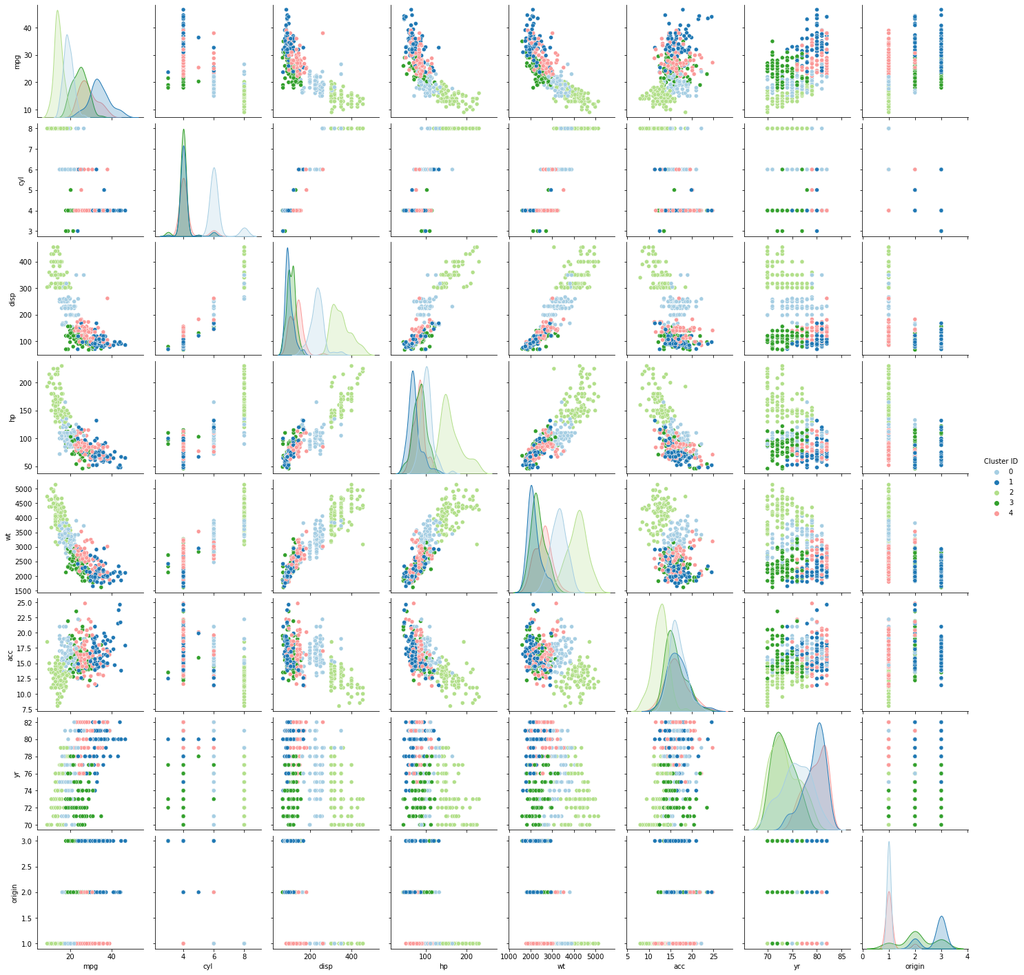

```python
sns.pairplot(df_head, diag_kind='kde', hue='Cluster ID', palette='Paired')
```

```python
# We can see that in most of the plots, there is significant separation between the clusters which indicates that the clustering was good and probably represent natural clusters
# We can see that roughly the mean mpg of the datapoints belonging to each cluster ID vary in the following order:
# cluster 1 > cluster 4 > cluster 3 > cluster 0 > cluster 2
```

### g. Pass a new DataPoint and predict which cluster it belongs to. [2 Marks]

```python
prediction2=final_model.predict(dfz_tail) #Running our final clustering model on the last row of the dataframe which we separated before
df_tail['Cluster ID'] = prediction2 # Adding the cluster prediction as a column to the dataframe
df_tail
# We see that the new datapoint has been classified into cluster 4
```

|  | car_name | mpg | cyl | disp | hp | wt | acc | yr | origin | Cluster ID |
| --- | --- | --- | --- | --- | --- | --- | --- | --- | --- | --- |
| 397 | chevy s-10 | 31.0 | 4 | 119.0 | 82.0 | 2720 | 19.4 | 82 | 1 | 4 |